# 蛋白保守序列分析

deming1024

2021年2月24日

生物体在基因或蛋白水平从来都不孤独的，往往都有一些共同的进化来源。通常来讲，在我们体内发挥重要功能的蛋白，也会在其他生物体中发挥功能。这类蛋白之间可能会存在以下一些情况：

- 有着类似的生物学功能
- 不同物种中还有额外功能
- 其他未知的功能

通过对蛋白保守区域的分析，可以帮助我们了解：**生物的起源**，**蛋白功能的演化**，**探索新的机制或功能**。

这里我们以DNA mismatch蛋白–MSH6为例，比较其蛋白MSH功能域在不同物种中的变化。

# 1 在NCBI中检索基因

根据Gene symbols，在NCBI数据库中检索对应基因编码的蛋白质序列

在5个物种中的MSH6蛋白中，均有4类MSH domains存在，但是在Rat中暂没注释信息。

| Species | GeneSymbol | MutS domain I | MutS domain II | MutS domain III | MutS domain IV | ProteinID |
| --- | --- | --- | --- | --- | --- | --- |
| human | MSH6 | 407525 | 538692 | 739827 | 932-1024 | NP_000170.1 |
| mouse | Msh6 | 406524 | 537689 | 736824 | 929-1021 | NP_034960.1 |
| rat | Msh6 | NA | NA | NA | NA | XP_038968982.1 |
| Zebrafish | msh6 | 406-524 | 537-693 | 740-828 | 933-1025 | NP_878280.1 |
| chicken | MSH6 | 391-509 | 522-674 | 721-839 | 914-1006 | XP_015133605.1 |
| monkey | MSH6 | 407-525 | 538-692 | 739-827 | 932-1024 | NP_001253005.1 |

**Note: MSH domain的注释信息来源于NCBI**

# 2 氨基酸序列比对

对6个物种中，全长氨基酸序列进行比对： “!”表示在所有比对物种中，氨基酸序列均一致。这里展示部分比对结果

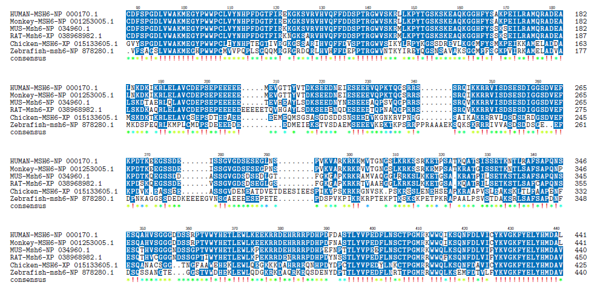

- 氨基酸序列在6个物种中较为保守

# 3 MSH Domain II局部比对

提取Human，Mouse的MSH DomainII 为参考，比较6个物种该段氨基酸序列，在Rat以及其他物种中的分布:

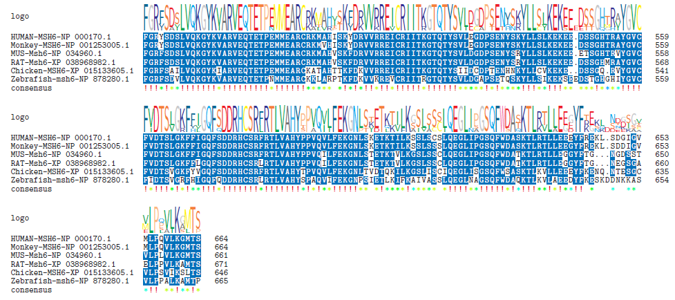

- 6个物种均存在MSH domain
- **Rat的Msh6蛋白序列中，也存在MSH Domain II**

# 4 MSH6蛋白进化树

根据MSH6的保守区域的比较结果，绘制MSH6在6个物种中的进化树。

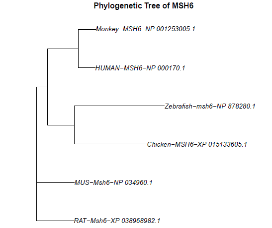

- Monkey,Human进化树上最为接近

**以上分析均采用R markdown完成**